# NYCCab

```python
import pandas as pd
import matplotlib.pyplot as plt
```

```python
df = pd.read_csv('green_tripdata_2016-02.csv')
```

```python
df.head(3)
```

|  | VendorID | lpep_pickup_datetime | Lpep_dropoff_datetime | Store_and_fwd_flag | RateCodeID | Pickup_longitude | Pickup_latitude | Dropoff_longitude | Dropoff_latitude | Passenger_count | ... | Fare_amount | Extra | MTA_tax | Tip_amount | Tolls_amount | Ehail_fee | improvement_surcharge | Total_amount | Payment_type | Trip_type |
| --- | --- | --- | --- | --- | --- | --- | --- | --- | --- | --- | --- | --- | --- | --- | --- | --- | --- | --- | --- | --- | --- |
| 0 | 2 | 2016-02-01 00:00:01 | 2016-02-01 00:10:06 | N | 1 | -73.939018 | 40.805214 | -73.972534 | 40.785885 | 1 | ... | 10.5 | 0.5 | 0.5 | 0.00 | 0.0 | NaN | 0.3 | 11.80 | 2 | 1.0 |
| 1 | 2 | 2016-02-01 00:01:33 | 2016-02-01 00:20:13 | N | 1 | -73.891495 | 40.746651 | -73.890877 | 40.743896 | 1 | ... | 13.0 | 0.5 | 0.5 | 0.00 | 0.0 | NaN | 0.3 | 14.30 | 2 | 1.0 |
| 2 | 2 | 2016-02-01 00:03:46 | 2016-02-01 00:21:04 | N | 1 | -73.983780 | 40.676132 | -73.956978 | 40.718327 | 1 | ... | 17.5 | 0.5 | 0.5 | 3.76 | 0.0 | NaN | 0.3 | 22.56 | 1 | 1.0 |

3 rows × 21 columns

```python
df.shape
```

```
(1510722, 21)
```

Question 1: As shown in output above, there are 1510722 rows and 21 columns in raw data

```python
df.columns
```

```
Index(['VendorID', 'lpep_pickup_datetime', 'Lpep_dropoff_datetime',
       'Store_and_fwd_flag', 'RateCodeID', 'Pickup_longitude',
       'Pickup_latitude', 'Dropoff_longitude', 'Dropoff_latitude',
       'Passenger_count', 'Trip_distance', 'Fare_amount', 'Extra', 'MTA_tax',
       'Tip_amount', 'Tolls_amount', 'Ehail_fee', 'improvement_surcharge',
       'Total_amount', 'Payment_type', 'Trip_type '],
      dtype='object')
```

```python
df['pickup_time'] = df['lpep_pickup_datetime'].str.split(' ').str[1]
```

```python
df['pickup_hour'] = df['pickup_time'].str.split(':').str[0]
```

```python
df = df.drop('pickup_time',axis = 1)
```

```python
df.head(3)
```

|  | VendorID | lpep_pickup_datetime | Lpep_dropoff_datetime | Store_and_fwd_flag | RateCodeID | Pickup_longitude | Pickup_latitude | Dropoff_longitude | Dropoff_latitude | Passenger_count | ... | Extra | MTA_tax | Tip_amount | Tolls_amount | Ehail_fee | improvement_surcharge | Total_amount | Payment_type | Trip_type | pickup_hour |
| --- | --- | --- | --- | --- | --- | --- | --- | --- | --- | --- | --- | --- | --- | --- | --- | --- | --- | --- | --- | --- | --- |
| 0 | 2 | 2016-02-01 00:00:01 | 2016-02-01 00:10:06 | N | 1 | -73.939018 | 40.805214 | -73.972534 | 40.785885 | 1 | ... | 0.5 | 0.5 | 0.00 | 0.0 | NaN | 0.3 | 11.80 | 2 | 1.0 | 00 |
| 1 | 2 | 2016-02-01 00:01:33 | 2016-02-01 00:20:13 | N | 1 | -73.891495 | 40.746651 | -73.890877 | 40.743896 | 1 | ... | 0.5 | 0.5 | 0.00 | 0.0 | NaN | 0.3 | 14.30 | 2 | 1.0 | 00 |
| 2 | 2 | 2016-02-01 00:03:46 | 2016-02-01 00:21:04 | N | 1 | -73.983780 | 40.676132 | -73.956978 | 40.718327 | 1 | ... | 0.5 | 0.5 | 3.76 | 0.0 | NaN | 0.3 | 22.56 | 1 | 1.0 | 00 |

3 rows × 22 columns

```python
df.groupby('pickup_hour')['Trip_distance'].describe()
```

| pickup_hour | count | mean | std | min | 25% | 50% | 75% | max |
| --- | --- | --- | --- | --- | --- | --- | --- | --- |
| 00 | 61840.0 | 2.800850 | 2.738892 | 0.0 | 1.05 | 1.93 | 3.59 | 72.02 |
| 01 | 46734.0 | 2.821077 | 2.736357 | 0.0 | 1.05 | 1.94 | 3.63 | 102.36 |
| 02 | 35677.0 | 2.942639 | 2.927170 | 0.0 | 1.07 | 2.03 | 3.82 | 124.34 |
| 03 | 27362.0 | 3.132550 | 3.194479 | 0.0 | 1.10 | 2.11 | 4.03 | 55.34 |
| 04 | 22425.0 | 3.415126 | 3.529225 | 0.0 | 1.15 | 2.23 | 4.35 | 44.09 |
| 05 | 14688.0 | 4.220526 | 4.418470 | 0.0 | 1.25 | 2.79 | 5.72 | 139.70 |
| 06 | 21225.0 | 4.010889 | 4.212022 | 0.0 | 1.29 | 2.80 | 5.46 | 235.50 |
| 07 | 43150.0 | 3.206017 | 3.253446 | 0.0 | 1.10 | 2.10 | 4.19 | 71.40 |
| 08 | 63088.0 | 2.875606 | 2.883974 | 0.0 | 1.00 | 1.86 | 3.79 | 78.80 |
| 09 | 65077.0 | 2.858318 | 2.931067 | 0.0 | 1.00 | 1.87 | 3.71 | 128.33 |
| 10 | 59121.0 | 2.790102 | 2.908105 | 0.0 | 0.99 | 1.80 | 3.57 | 104.60 |
| 11 | 58755.0 | 2.767530 | 2.948458 | 0.0 | 0.99 | 1.79 | 3.50 | 114.32 |
| 12 | 58861.0 | 2.745999 | 2.875479 | 0.0 | 1.00 | 1.78 | 3.43 | 62.47 |
| 13 | 63102.0 | 2.739013 | 2.941122 | 0.0 | 0.99 | 1.74 | 3.40 | 72.99 |
| 14 | 70376.0 | 2.680709 | 2.934420 | 0.0 | 0.98 | 1.70 | 3.25 | 77.33 |
| 15 | 75376.0 | 2.617149 | 2.895358 | 0.0 | 0.98 | 1.69 | 3.16 | 116.18 |
| 16 | 84570.0 | 2.532882 | 2.732724 | 0.0 | 0.97 | 1.65 | 3.09 | 70.31 |
| 17 | 93849.0 | 2.471135 | 2.555930 | 0.0 | 0.98 | 1.64 | 3.03 | 45.03 |
| 18 | 105342.0 | 2.422031 | 2.446833 | 0.0 | 0.97 | 1.62 | 3.00 | 105.89 |
| 19 | 103394.0 | 2.439268 | 2.448598 | 0.0 | 0.97 | 1.64 | 3.04 | 106.16 |
| 20 | 93850.0 | 2.518246 | 2.629491 | 0.0 | 0.99 | 1.69 | 3.16 | 216.40 |
| 21 | 86731.0 | 2.614882 | 2.599543 | 0.0 | 1.00 | 1.76 | 3.31 | 73.15 |
| 22 | 80987.0 | 2.780947 | 2.761013 | 0.0 | 1.02 | 1.87 | 3.58 | 130.31 |
| 23 | 75142.0 | 2.847825 | 2.775861 | 0.0 | 1.06 | 1.94 | 3.68 | 131.40 |

```
Text(0,0.5,'Trip Distance (mile)')
```

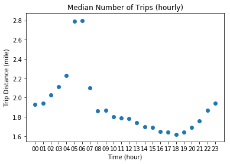

```python
# line plot for median trip distance by hour
plt.scatter(df['pickup_hour'].unique(), df.groupby('pickup_hour')['Trip_distance'].median())
plt.title('Median Number of Trips (hourly)')
plt.xlabel('Time (hour)')
plt.ylabel('Trip Distance (mile)')
```

```
Text(0,0.5,'Trip Distance (mile)')
```

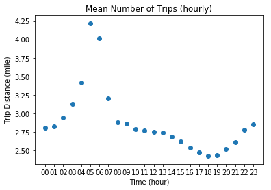

```python
# line plot for mean trip distance by hour
plt.scatter(df['pickup_hour'].unique(), df.groupby('pickup_hour')['Trip_distance'].mean())
plt.title('Mean Number of Trips (hourly)')
plt.xlabel('Time (hour)')
plt.ylabel('Trip Distance (mile)')
```

Question 2: The mean and median charts above show that trip distance (grouped by pick up hour) is much longer than usual between 2am and 7am. There is also a small dip in trip distance from 3pm - 9pm.

```python
df.head(3)
```

|  | VendorID | lpep_pickup_datetime | Lpep_dropoff_datetime | Store_and_fwd_flag | RateCodeID | Pickup_longitude | Pickup_latitude | Dropoff_longitude | Dropoff_latitude | Passenger_count | ... | Extra | MTA_tax | Tip_amount | Tolls_amount | Ehail_fee | improvement_surcharge | Total_amount | Payment_type | Trip_type | pickup_hour |
| --- | --- | --- | --- | --- | --- | --- | --- | --- | --- | --- | --- | --- | --- | --- | --- | --- | --- | --- | --- | --- | --- |
| 0 | 2 | 2016-02-01 00:00:01 | 2016-02-01 00:10:06 | N | 1 | -73.939018 | 40.805214 | -73.972534 | 40.785885 | 1 | ... | 0.5 | 0.5 | 0.00 | 0.0 | NaN | 0.3 | 11.80 | 2 | 1.0 | 00 |
| 1 | 2 | 2016-02-01 00:01:33 | 2016-02-01 00:20:13 | N | 1 | -73.891495 | 40.746651 | -73.890877 | 40.743896 | 1 | ... | 0.5 | 0.5 | 0.00 | 0.0 | NaN | 0.3 | 14.30 | 2 | 1.0 | 00 |
| 2 | 2 | 2016-02-01 00:03:46 | 2016-02-01 00:21:04 | N | 1 | -73.983780 | 40.676132 | -73.956978 | 40.718327 | 1 | ... | 0.5 | 0.5 | 3.76 | 0.0 | NaN | 0.3 | 22.56 | 1 | 1.0 | 00 |

3 rows × 22 columns

```python
df['pickup_date'] = df['lpep_pickup_datetime'].str.split(' ').str[0]
df['pickup_date'] = pd.to_datetime(df['pickup_date'])
```

```python
def checkWeekDay(x):
    return x.weekday()
df['WeekDay'] = df['pickup_date'].apply(lambda x: checkWeekDay(x))
```

```python
df.groupby('WeekDay').size()
```

```
WeekDay
0    213205
1    176276
2    188564
3    206268
4    234141
5    269216
6    223052
dtype: int64
```

```python
df.head(3)
```

|  | VendorID | lpep_pickup_datetime | Lpep_dropoff_datetime | Store_and_fwd_flag | RateCodeID | Pickup_longitude | Pickup_latitude | Dropoff_longitude | Dropoff_latitude | Passenger_count | ... | Tip_amount | Tolls_amount | Ehail_fee | improvement_surcharge | Total_amount | Payment_type | Trip_type | pickup_hour | pickup_date | WeekDay |
| --- | --- | --- | --- | --- | --- | --- | --- | --- | --- | --- | --- | --- | --- | --- | --- | --- | --- | --- | --- | --- | --- |
| 0 | 2 | 2016-02-01 00:00:01 | 2016-02-01 00:10:06 | N | 1 | -73.939018 | 40.805214 | -73.972534 | 40.785885 | 1 | ... | 0.00 | 0.0 | NaN | 0.3 | 11.80 | 2 | 1.0 | 00 | 2016-02-01 | 0 |
| 1 | 2 | 2016-02-01 00:01:33 | 2016-02-01 00:20:13 | N | 1 | -73.891495 | 40.746651 | -73.890877 | 40.743896 | 1 | ... | 0.00 | 0.0 | NaN | 0.3 | 14.30 | 2 | 1.0 | 00 | 2016-02-01 | 0 |
| 2 | 2 | 2016-02-01 00:03:46 | 2016-02-01 00:21:04 | N | 1 | -73.983780 | 40.676132 | -73.956978 | 40.718327 | 1 | ... | 3.76 | 0.0 | NaN | 0.3 | 22.56 | 1 | 1.0 | 00 | 2016-02-01 | 0 |

3 rows × 24 columns

```python
dfweekend = df[df['WeekDay'] >= 5]
dfweekday = df[df['WeekDay'] < 5]
```

```
Text(0,0.5,'latitude')
```

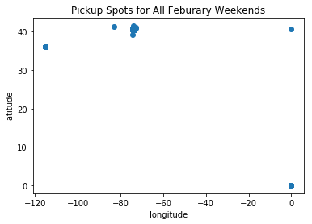

```python
#From the graph below, it's clear that some data points should be discarded; pickup location should be inside
#[40, 41] and [-75, -73] for NYC
plt.scatter(dfweekend['Pickup_longitude'], dfweekend['Pickup_latitude'])
plt.title('Pickup Spots for All Feburary Weekends')
plt.xlabel('longitude')
plt.ylabel('latitude')
```

```python
dfweekend = dfweekend[(dfweekend['Pickup_latitude'] > 40) & (dfweekend['Pickup_latitude'] < 41) &
                     (dfweekend['Pickup_longitude'] > -75) & (dfweekend['Pickup_longitude'] < -73)]
```

```python
dfweekday = dfweekday[(dfweekday['Pickup_latitude'] > 40) & (dfweekday['Pickup_latitude'] < 41) &
                     (dfweekday['Pickup_longitude'] > -75) & (dfweekday['Pickup_longitude'] < -73)]
```

```python
#~3000 data points were removed
print(df.shape[0] - dfweekday.shape[0] - dfweekend.shape[0])
```

```
2929
```

```
Text(0,0.5,'latitude')
```

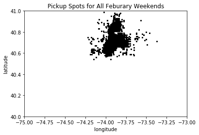

```python
# weekend pickup spots
dfweekend['Pickup_longitude'] = dfweekend['Pickup_longitude'].round(2)
dfweekend['Pickup_latitude'] = dfweekend['Pickup_latitude'].round(2)
plt.scatter(dfweekend['Pickup_longitude'], dfweekend['Pickup_latitude'], marker = 'x', color = 'k', s = 5)
plt.xlim(-75, -73)
plt.ylim(40, 41)
plt.title('Pickup Spots for All Feburary Weekends')
plt.xlabel('longitude')
plt.ylabel('latitude')
```

```
Text(0,0.5,'latitude')
```

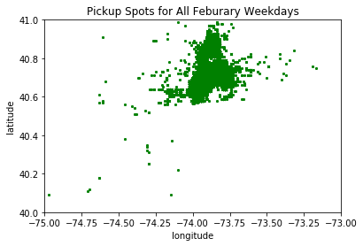

```python
# weekday pickup spots
dfweekday['Pickup_longitude'] = dfweekday['Pickup_longitude'].round(2)
dfweekday['Pickup_latitude'] = dfweekday['Pickup_latitude'].round(2)
plt.scatter(dfweekday['Pickup_longitude'], dfweekday['Pickup_latitude'], marker = 'x', color = 'g', s = 5)
plt.xlim(-75, -73)
plt.ylim(40, 41)
plt.title('Pickup Spots for All Feburary Weekdays')
plt.xlabel('longitude')
plt.ylabel('latitude')
```

```python
dfweekday['Pickup_loc'] = dfweekday['Pickup_longitude'].astype(str) + ', ' + dfweekday['Pickup_latitude'].astype(str)
```

```python
dfweekend['Pickup_loc'] = dfweekend['Pickup_longitude'].astype(str) + ', ' + dfweekend['Pickup_latitude'].astype(str)
```

```python
dfweekday.groupby('Pickup_loc').size().sort_values(ascending = False).head(5)
```

```
Pickup_loc
-73.95, 40.79    49751
-73.99, 40.69    44378
-73.95, 40.81    33939
-73.94, 40.81    32732
-73.96, 40.81    30017
dtype: int64
```

```python
dfweekend.groupby('Pickup_loc').size().sort_values(ascending = False).head(5)
```

```
Pickup_loc
-73.96, 40.72    23594
-73.99, 40.69    16920
-73.95, 40.81    16896
-73.89, 40.75    15831
-73.98, 40.68    15681
dtype: int64
```

```python
dftarget = df[(df['pickup_date'] == '2016-02-12') & (df['pickup_hour'] > '10') & (df['pickup_hour'] <= '20')]
```

```python
#actual number of trips by hour on Feb 12 between 11:00 - 20:00
target = dftarget.groupby('pickup_hour', as_index = False).size()
target = target.reset_index()
target = target.rename(columns = {0:'numTrip'})
target
```

|  | pickup_hour | numTrip |
| --- | --- | --- |
| 0 | 11 | 2175 |
| 1 | 12 | 2024 |
| 2 | 13 | 2106 |
| 3 | 14 | 2716 |
| 4 | 15 | 3009 |
| 5 | 16 | 3517 |
| 6 | 17 | 4040 |
| 7 | 18 | 4564 |
| 8 | 19 | 4725 |
| 9 | 20 | 4432 |

```python
#use other Fridays in Feburary dataset for predicting Feb 12's hourly trip numbers
dffriday = df[(df['pickup_date'] != '2016-02-12') & (df['pickup_hour'] > '10') & (df['pickup_hour'] <= '20') &
            (df['WeekDay'] == 4)]
```

```python
dffriday = dffriday.groupby(['pickup_hour', 'pickup_date'], as_index = False).size()
dffriday = dffriday.reset_index()
dffriday = dffriday.rename(columns = {0:'numTrip'})
dffriday
```

|  | pickup_hour | pickup_date | numTrip |
| --- | --- | --- | --- |
| 0 | 11 | 2016-02-05 | 1943 |
| 1 | 11 | 2016-02-19 | 1974 |
| 2 | 11 | 2016-02-26 | 1975 |
| 3 | 12 | 2016-02-05 | 1750 |
| 4 | 12 | 2016-02-19 | 1892 |
| 5 | 12 | 2016-02-26 | 1830 |
| 6 | 13 | 2016-02-05 | 1693 |
| 7 | 13 | 2016-02-19 | 1895 |
| 8 | 13 | 2016-02-26 | 1986 |
| 9 | 14 | 2016-02-05 | 2186 |
| 10 | 14 | 2016-02-19 | 2298 |
| 11 | 14 | 2016-02-26 | 2473 |
| 12 | 15 | 2016-02-05 | 2505 |
| 13 | 15 | 2016-02-19 | 2618 |
| 14 | 15 | 2016-02-26 | 2805 |
| 15 | 16 | 2016-02-05 | 2970 |
| 16 | 16 | 2016-02-19 | 3269 |
| 17 | 16 | 2016-02-26 | 3236 |
| 18 | 17 | 2016-02-05 | 3492 |
| 19 | 17 | 2016-02-19 | 3639 |
| 20 | 17 | 2016-02-26 | 3871 |
| 21 | 18 | 2016-02-05 | 4115 |
| 22 | 18 | 2016-02-19 | 4294 |
| 23 | 18 | 2016-02-26 | 4480 |
| 24 | 19 | 2016-02-05 | 4225 |
| 25 | 19 | 2016-02-19 | 4314 |
| 26 | 19 | 2016-02-26 | 4690 |
| 27 | 20 | 2016-02-05 | 3761 |
| 28 | 20 | 2016-02-19 | 3938 |
| 29 | 20 | 2016-02-26 | 4431 |

```python
# support vector regressor model
from sklearn.svm import SVR
svr = SVR(kernel='rbf', C=1e3, gamma=0.1)
x_train = dffriday['pickup_hour'].values.reshape(-1, 1)
x_test = target['pickup_hour'].values.reshape(-1, 1)
y_train = dffriday['numTrip']
model_svr = svr.fit(x_train, y_train)
y_svr = model_svr.predict(x_test)
```

```python
# simple model that returns mean of training set for that hour
y_sim = dffriday.groupby('pickup_hour').mean()
```

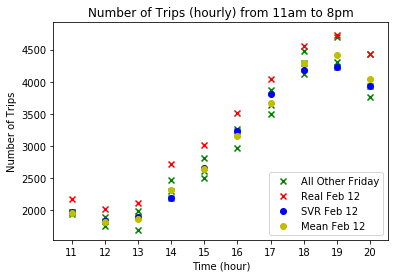

```python
plt.scatter(dffriday['pickup_hour'], dffriday['numTrip'], marker = 'x', color = 'g', label = 'All Other Friday')
plt.scatter(target['pickup_hour'], target['numTrip'], marker = 'x', color = 'r', label = 'Real Feb 12')
plt.scatter(target['pickup_hour'], y_svr, marker = 'o', color = 'b', label = 'SVR Feb 12')
plt.scatter(target['pickup_hour'], y_sim, marker = 'o', color = 'y', label = 'Mean Feb 12')
plt.title('Number of Trips (hourly) from 11am to 8pm')
plt.legend(loc = 'lower right')
plt.xlabel('Time (hour)')
plt.ylabel('Number of Trips')
plt.show()
```

```python
from sklearn.metrics import mean_squared_error
error_svr = mean_squared_error(target['numTrip'], y_svr)
error_sim = mean_squared_error(target['numTrip'], y_sim)
print('svr model error: ' + str(error_svr))
print('simple model error: ' + str(error_sim))
```

```
svr model error: 129328.5382561961
simple model error: 102749.86666666662
```

Question 4: Since Feb 12's trip number for a given hour is much higher than that of other Friday's in Feburary, both svr model and simple mean model are not able to match the target perfectly.